# 03 Analysis

## Fig 3 Gov Redist

### Adjusted

```r
# check
agg_png(here::here("results", "Fig3_redist.png"), res = 144, height = 600, width = 1000)
ggplot(df_macro, aes(y = gov_redist_socx_resid, x = soc_sec_age)) +
  geom_point(aes(color = type_7, shape = type_7)) +
  scale_color_viridis_d() +
  scale_shape_manual(values = c(15,16,17,8,9,10,11)) +
  geom_smooth(se=FALSE, method="gam", span=0.5) +
  labs(y = "Support for Redistribution",
       x = "Cumulative Age of Social Policies",
       color = "Regime Type", shape = "Regime Type") +
  theme_classic()
dev.off()
```

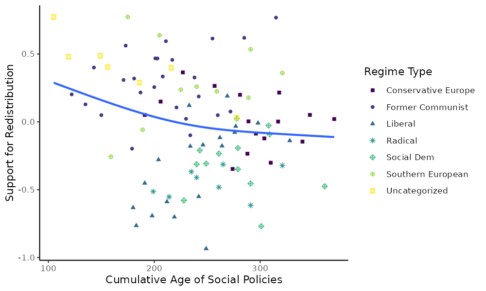

```r
knitr::include_graphics(here::here("results", "Fig3_redist.png"))
```

### Raw

```r
# check
agg_png(here::here("results", "Fig3_redist_raw.png"), res = 144, height = 600, width = 1000)
ggplot(df_macro, aes(y = gov_redist, x = soc_sec_age)) +
  geom_point(aes(color = type_7, shape = type_7)) +
  scale_color_viridis_d() +
  scale_shape_manual(values = c(15,16,17,8,9,10,11)) +
  geom_smooth(se=FALSE, method="gam", span=0.5) +
  labs(y = "Support for Redistribution",
       x = "Cumulative Age of Social Policies",
       color = "Regime Type", shape = "Regime Type") +
  theme_classic()
dev.off()
```

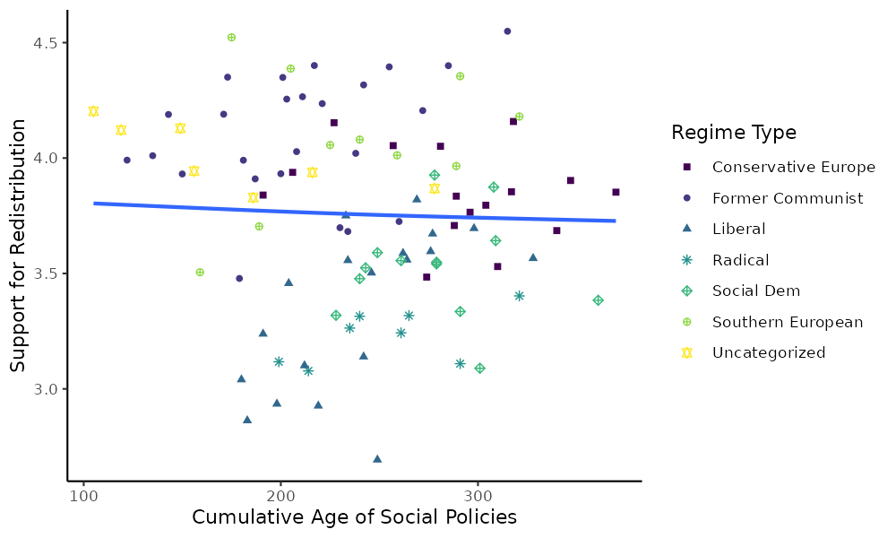

```r
knitr::include_graphics(here::here("results", "Fig3_redist_raw.png"))
```

## Fig 4 WS Support

### Adjusted

```r
agg_png(here::here("results", "Fig4_wssupport.png"), res = 144, height = 600, width = 1000)
ggplot(df_macro_rog, aes(y = gint_socx_resid, x = soc_sec_age)) +
  geom_point(aes(color = type_8, shape = type_8)) +
  scale_color_viridis_d() +
  scale_shape_manual(values = c(15,16,18,17,8,9,10,11)) +
  geom_smooth(se=FALSE, method="gam", span=0.5) +
  labs(y = "Support for the Welfare State",
       x = "Cumulative Age of Social Policies",
       color = "Regime Type", shape = "Regime Type") +
  theme_classic()
dev.off()
```

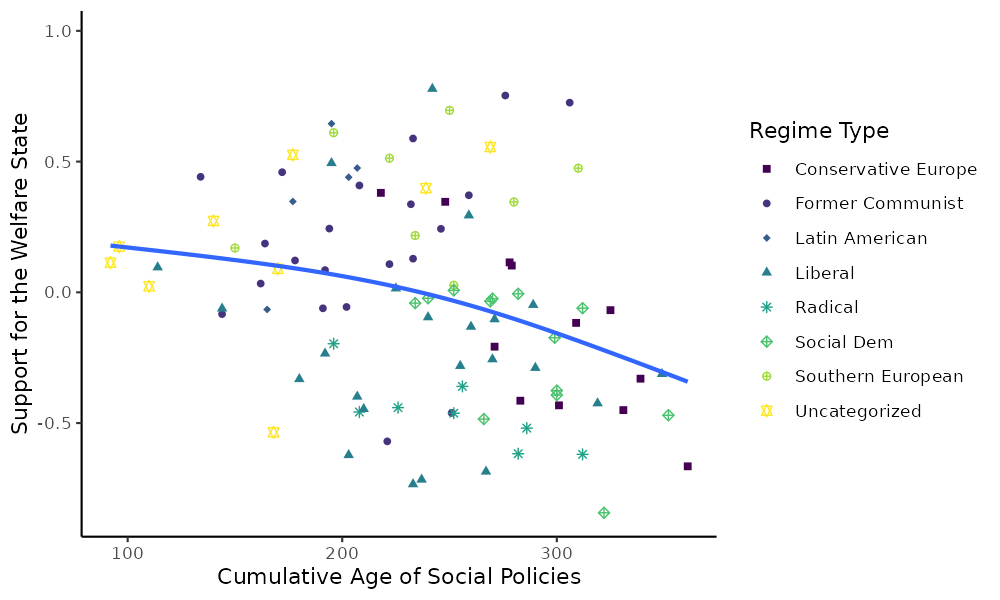

```r
knitr::include_graphics(here::here("results", "Fig4_wssupport.png"))
```

### Raw

```r
agg_png(here::here("results", "Fig4_wssupport_raw.png"), res = 144, height = 600, width = 1000)
ggplot(df_macro_rog, aes(y = gint, x = soc_sec_age)) +
  geom_point(aes(color = type_8, shape = type_8)) +
  scale_color_viridis_d() +
  scale_shape_manual(values = c(15,16,18,17,8,9,10,11)) +
  geom_smooth(se=FALSE, method="gam", span=0.5) +
  labs(y = "Support for the Welfare State",
       x = "Cumulative Age of Social Policies",
       color = "Regime Type", shape = "Regime Type") +
  theme_classic()
dev.off()
```

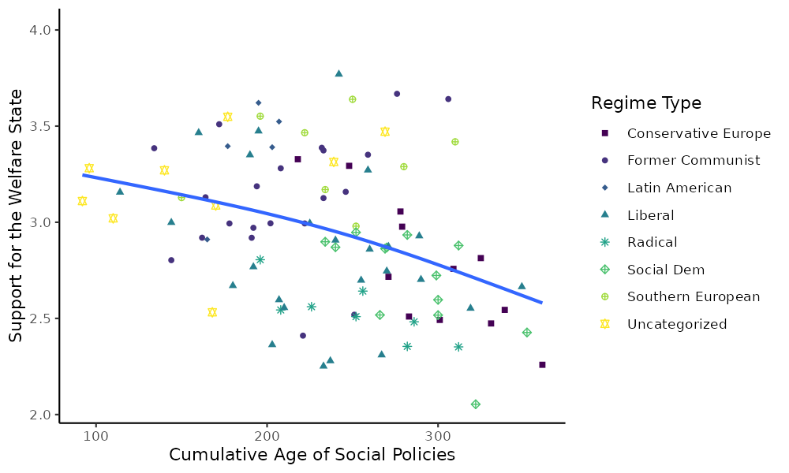

```r
knitr::include_graphics(here::here("results", "Fig4_wssupport_raw.png"))
```

## Fig 5 Liberal Values

```r
agg_png(here::here("results", "Fig5_liberal.png"), res = 144, height = 600, width = 1000)
ggplot(df_macro, aes(y = liberal_redist_i, x = soc_sec_age)) +
  geom_point(aes(color = type_7, shape = type_7)) +
  scale_color_viridis_d() +
  scale_shape_manual(values = c(15,16,17,8,9,10,11)) +
  geom_smooth(se=FALSE, method="gam", span=0.5) +
  labs(y = "Liberal Values",
       x = "Cumulative Age of Social Policies",
       color = "Regime Type", shape = "Regime Type") +
  theme_classic()
dev.off()
```

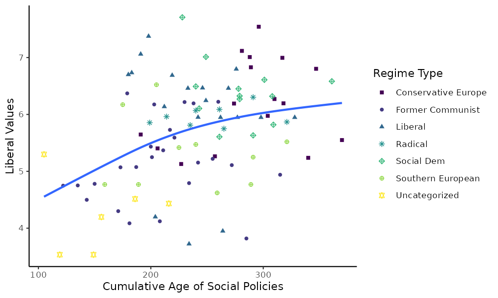

```r
knitr::include_graphics(here::here("results", "Fig5_liberal.png"))
```

### Final Variable Mods Dummy for former communist Re-scale for easier regression results Plot_summs does not standardize the variables properly, so scale them here

```r
df_macro <- df_macro %>%
  mutate(fcomm = ifelse(type_7 == "Former Communist", 1, 0),
         soc_sec_age_100 = soc_sec_age/100,
         w = 6) %>%
  group_by(iso3c) %>%
  mutate(groupn = n()) %>%
  ungroup() %>%
  mutate(weight = w/groupn)

df_macro_rog <- df_macro_rog %>%
  mutate(fcomm = ifelse(type_8 == "Former Communist", 1, 0),
         soc_sec_age_100 = soc_sec_age/100,
         w = 6) %>%
  group_by(iso3c) %>%
  mutate(groupn = n()) %>%
  ungroup() %>%
  mutate(weight = w/groupn)

# count countries, generate weights
```

## Regressions

### Standard

```r
#without former communist
reg1 <- lm(gov_redist ~ soc_sec_age_100 + socx_C, data = df_macro)
reg2 <- lm(gint ~ soc_sec_age_100 + socx_C, data = df_macro_rog)
reg3 <- lm(liberal_redist_i ~ soc_sec_age_100 + socx_C, data = df_macro)
# standardize
reg1Z <- scale_mod(reg1, scale.response = T)
reg2Z <- scale_mod(reg2, scale.response = T)
reg3Z <- scale_mod(reg3, scale.response = T)
#with
reg4 <- lm(gov_redist ~ soc_sec_age_100 + socx_C + fcomm, data = df_macro)
reg5 <- lm(gint ~ soc_sec_age_100 + socx_C + fcomm, data = df_macro_rog)
reg6 <- lm(liberal_redist_i ~ soc_sec_age_100 + socx_C + fcomm, data = df_macro)
# standardize
reg4Z <- scale_mod(reg4, scale.response = T)
reg5Z <- scale_mod(reg5, scale.response = T)
reg6Z <- scale_mod(reg6, scale.response = T)
```

### Weighted

```r
#without former communist
reg1w <- lm(gov_redist ~ soc_sec_age_100 + socx_C, data = df_macro, weights = weight)
reg2w <- lm(gint ~ soc_sec_age_100 + socx_C, data = df_macro_rog, weights = weight)
reg3w <- lm(liberal_redist_i ~ soc_sec_age_100 + socx_C, data = df_macro, weights = weight)
# standardize
reg1wZ <- scale_mod(reg1w, scale.response = T)
reg2wZ <- scale_mod(reg2w, scale.response = T)
reg3wZ <- scale_mod(reg3w, scale.response = T)
#with
reg4w <- lm(gov_redist ~ soc_sec_age_100 + socx_C + fcomm, data = df_macro, weights = weight)
reg5w <- lm(gint ~ soc_sec_age_100 + socx_C + fcomm, data = df_macro_rog, weights = weight)
reg6w <- lm(liberal_redist_i ~ soc_sec_age_100 + socx_C + fcomm, data = df_macro, weights = weight)
# standardize
reg4wZ <- scale_mod(reg4w, scale.response = T)
reg5wZ <- scale_mod(reg5w, scale.response = T)
reg6wZ <- scale_mod(reg6w, scale.response = T)
```

### Coef plot

#### Standard

Standardize for ease of interpretation

```r
agg_png(filename = here::here("results", "Fig6a.png"), res = 144, height = 400, width = 400)
plot_summs(reg4Z, reg5Z, reg6Z,
           coefs = c("Age of\nSocial Security" = "soc_sec_age_100",
                     "SOCX\nCountry Mean" = "socx_C",
                     "Former\nCommunist" = "fcomm"),
           colors = c("#287D8EFF", "#453781FF", "#73D055FF")) +
           theme(legend.position = "none")

dev.off()
```

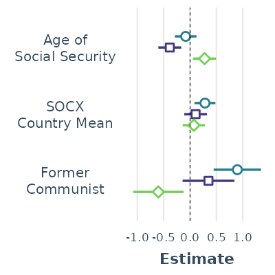

```r
knitr::include_graphics(here::here("results", "Fig6a.png"))
```

```r
agg_png(filename = here::here("results", "Fig6b.png"), res = 144, height = 315, width = 550)
plot_summs(reg1Z, reg2Z, reg3Z,
           coefs = c(" " = "soc_sec_age_100",
                     "  " = "socx_C"),
           model.names = c("Support for\nRedistribution",
                           "Support for\nthe Welfare State",
                           "Liberal Values"),
           colors = c("#287D8EFF", "#453781FF", "#73D055FF"))

dev.off()
```

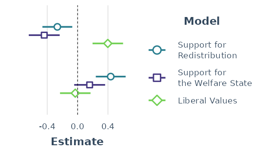

```r
knitr::include_graphics(here::here("results", "Fig6b.png"))
```

### Regression Tables

#### Standard

```r
tab_model(reg1Z,reg2Z,reg3Z,reg4Z,reg5Z,reg6Z, p.style = "stars", show.ci = F,
          pred.labels = c("(Intercept)",
                          "Age of Social Security",
                          "Social Spending",
                          "Former Communist"),
          dv.labels = c("Support for Redistri- bution",
                        "Support for Welfare State",
                        "Liberal Values",
                        "Support for Redistri- bution",
                        "Support for Welfare State",
                        "Liberal Values"),
          file = here::here("results","Table1.doc"))
```

Support for Redistri- bution

Support for Welfare State

Liberal Values

Support for Redistri- bution

Support for Welfare State

Liberal Values

Predictors

Estimates

Estimates

Estimates

Estimates

Estimates

Estimates

(Intercept)

-0.00

0.00

-0.00

-0.23 *

-0.07

0.16

Age of Social Security

-0.27 **

-0.44 ***

0.40 ***

-0.08

-0.38 ***

0.28 *

Social Spending

0.44 ***

0.16

-0.03

0.28 **

0.11

0.07

Former Communist

0.90 ***

0.35

-0.60 *

Observations

98

99

97

98

99

97

R<sup>2</sup> / R<sup>2</sup> adjusted

0.181 / 0.163

0.161 / 0.143

0.151 / 0.133

0.298 / 0.276

0.178 / 0.152

0.204 / 0.178

- p<0.05 ** p<0.01 *** p<0.001

```r
tab_model(reg1Z,reg2Z,reg3Z,reg4Z,reg5Z,reg6Z, p.style = "stars", show.ci = F,
          pred.labels = c("(Intercept)",
                          "Age of Social Security",
                          "Social Spending",
                          "Former Communist"),
          dv.labels = c("Support for Redistri- bution",
                        "Support for Welfare State",
                        "Liberal Values",
                        "Support for Redistri- bution",
                        "Support for Welfare State",
                        "Liberal Values"))
```

Support for Redistri- bution

Support for Welfare State

Liberal Values

Support for Redistri- bution

Support for Welfare State

Liberal Values

Predictors

Estimates

Estimates

Estimates

Estimates

Estimates

Estimates

(Intercept)

-0.00

0.00

-0.00

-0.23 *

-0.07

0.16

Age of Social Security

-0.27 **

-0.44 ***

0.40 ***

-0.08

-0.38 ***

0.28 *

Social Spending

0.44 ***

0.16

-0.03

0.28 **

0.11

0.07

Former Communist

0.90 ***

0.35

-0.60 *

Observations

98

99

97

98

99

97

R<sup>2</sup> / R<sup>2</sup> adjusted

0.181 / 0.163

0.161 / 0.143

0.151 / 0.133

0.298 / 0.276

0.178 / 0.152

0.204 / 0.178

- p<0.05 ** p<0.01 *** p<0.001

#### Weighted

```r
tab_model(reg1wZ,reg2wZ,reg3wZ,reg4wZ,reg5wZ,reg6wZ, p.style = "stars", show.ci = F,
          pred.labels = c("(Intercept)",
                          "Age of Social Security",
                          "Social Spending",
                          "Former Communist"),
          dv.labels = c("Support for Redistri- bution",
                        "Support for Welfare State",
                        "Liberal Values",
                        "Support for Redistri- bution",
                        "Support for Welfare State",
                        "Liberal Values"),
          file = here::here("results","Table2.doc"))
```

Support for Redistri- bution

Support for Welfare State

Liberal Values

Support for Redistri- bution

Support for Welfare State

Liberal Values

Predictors

Estimates

Estimates

Estimates

Estimates

Estimates

Estimates

(Intercept)

0.00

-0.00

-0.00

-0.19

-0.07

0.13

Age of Social Security

-0.39 ***

-0.50 ***

0.44 ***

-0.22 *

-0.45 ***

0.34 **

Social Spending

0.41 ***

0.24 *

-0.02

0.25 *

0.19

0.08

Former Communist

0.81 **

0.33

-0.52 *

Observations

98

99

97

98

99

97

R<sup>2</sup> / R<sup>2</sup> adjusted

0.168 / 0.150

0.191 / 0.174

0.187 / 0.169

0.258 / 0.234

0.208 / 0.183

0.225 / 0.200

- p<0.05 ** p<0.01 *** p<0.001

```r
tab_model(reg1wZ,reg2wZ,reg3wZ,reg4wZ,reg5wZ,reg6wZ, p.style = "stars", show.ci = F,
          pred.labels = c("(Intercept)",
                          "Age of Social Security",
                          "Social Spending",
                          "Former Communist"),
          dv.labels = c("Support for Redistri- bution",
                        "Support for Welfare State",
                        "Liberal Values",
                        "Support for Redistri- bution",
                        "Support for Welfare State",
                        "Liberal Values"))
```

Support for Redistri- bution

Support for Welfare State

Liberal Values

Support for Redistri- bution

Support for Welfare State

Liberal Values

Predictors

Estimates

Estimates

Estimates

Estimates

Estimates

Estimates

(Intercept)

0.00

-0.00

-0.00

-0.19

-0.07

0.13

Age of Social Security

-0.39 ***

-0.50 ***

0.44 ***

-0.22 *

-0.45 ***

0.34 **

Social Spending

0.41 ***

0.24 *

-0.02

0.25 *

0.19

0.08

Former Communist

0.81 **

0.33

-0.52 *

Observations

98

99

97

98

99

97

R<sup>2</sup> / R<sup>2</sup> adjusted

0.168 / 0.150

0.191 / 0.174

0.187 / 0.169

0.258 / 0.234

0.208 / 0.183

0.225 / 0.200

- p<0.05 ** p<0.01 *** p<0.001